# Лабораторная работа №3

Настройка DHCP-сервера

Жукова Арина Александровна

1132239120@rudn.ru

Российский университет дружбы народов

2025-12-15

# Информация

## Докладчик

- Жукова Арина Александровна
- студентка 3 курса
- направление: Прикладная информатика
- Российский университет дружбы народов им. П. Лумумбы
- 1132239120@rudn.ru

# Вводная часть

## Актуальность

- DHCP - критически важный протокол для автоматизации сетевых настроек
- Исключает ручное назначение IP-адресов, предотвращая конфликты
- Стандарт де-факто для корпоративных и домашних сетей
- Необходимый навык для сетевых администраторов и инженеров

## Объект и предмет исследования

- **Объект**: DHCP-сервер и его конфигурация
- **Предмет**: Процесс установки, настройки и интеграции DHCP-сервера с DNS

## Цели и задачи

**Цель**: Приобретение практических навыков по установке и конфигурированию DHCP-сервера.

**Задачи**:

1. Установить и настроить DHCP-сервер на виртуальной машине
2. Интегрировать DHCP с DNS для динамического обновления записей
3. Проверить корректность работы в виртуальной сети
4. Автоматизировать процесс настройки через Vagrant

## Материалы и методы

- Виртуальные машины (Server и Client)
- ПО: Kea DHCP Server, BIND9 DNS Server
- ОС: Linux (дистрибутив на основе RHEL)
- Инструменты: Vagrant для автоматизации, утилиты диагностики (ifconfig, dig)

# Установка и базовая настройка DHCP

## Установка DHCP-сервера

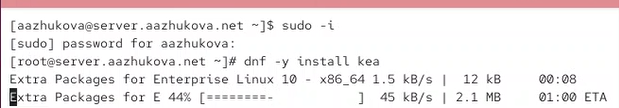

- Команда: `dnf install -y kea`
- Установка пакета kea-dhcp4-server
- Автоматическое разрешение зависимостей

## Конфигурация DHCP-сервера

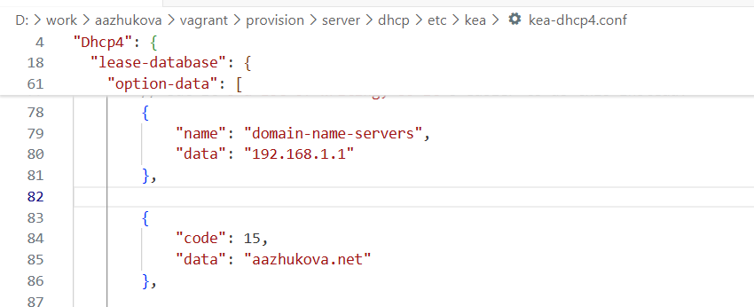

- Настройка файла `/etc/kea/kea-dhcp4.conf`
- Определение подсети: 192.168.1.0/24
- Настройка DNS-серверов и доменного имени
- Назначение диапазона адресов: 192.168.1.30-192.168.1.100

## Привязка к сетевому интерфейсу

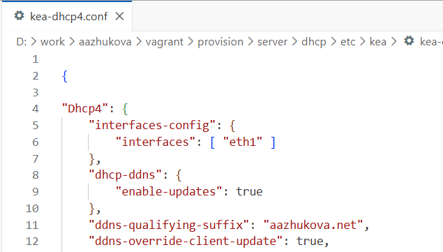

# Интеграция с DNS

## Настройка DNS-записей

**Прямая зона**

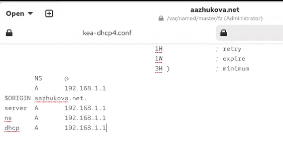

**Обратная зона**

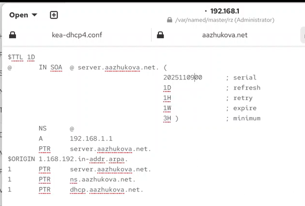

- Добавление A-записи для DHCP-сервера
- Настройка PTR-записи для обратного разрешения
- Проверка: `nslookup dhcp.aazhukova.net`

## Настройка динамического обновления DNS (DDNS)

### Создание ключа TSIG

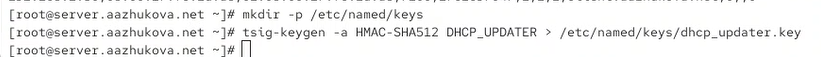

- Генерация ключа: `tsig-keygen -a hmac-sha512 DHCP_UPDATER`
- Алгоритм: HMAC-SHA512
- Копирование ключа в `/etc/named/keys/`

## Настройка динамического обновления DNS (DDNS)

### Конфигурация BIND9 для DDNS

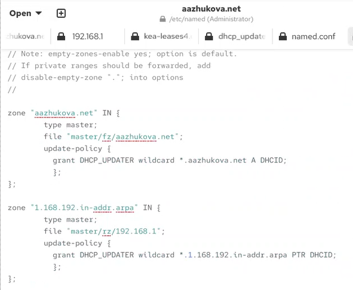

Обновление зоны

- Разрешение обновления зоны в `named.conf`
- Настройка политик доступа
- Проверка конфигурации: `named-checkconf`

# Проверка работы DHCP

## Запуск клиента и проверка конфигурации

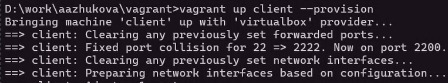

- Запуск виртуальной машины client: `vagrant up client --provision`
- Настройка маршрутизации через скрипт provisioning